# final-proj

## Data Description

Data - Daily historical sales data.  
Task - Forecast the total amount of products sold in every shop for the test set.

Note: The list of shops and products slightly changes every month. Creating a robust model that can handle such situations is part of the challenge.

## Data Files

**sales_train.csv** - Training set. Daily historical data from January 2013 to October 2015.  
**test.csv** - Test set. Forecast the sales for these shops and products for November 2015.

**items.csv** - supplemental information about the items/products.  
**item_categories.csv** - supplemental information about the items categories.  
**shops.csv** - supplemental information about the shops.

```python
import numpy as np
import pandas as pd
import matplotlib.pyplot as plt
```

```python
sales_train = pd.read_csv('../input/competitive-data-science-predict-future-sales/sales_train.csv')
test = pd.read_csv('/kaggle/input/competitive-data-science-predict-future-sales/test.csv')
items = pd.read_csv('../input/competitive-data-science-predict-future-sales/items.csv')
item_categories = pd.read_csv('../input/competitive-data-science-predict-future-sales/item_categories.csv')
shops = pd.read_csv('../input/competitive-data-science-predict-future-sales/shops.csv')
```

```python
h_r = 3
sales_train.head(h_r)
```

|  | date | date_block_num | shop_id | item_id | item_price | item_cnt_day |
| --- | --- | --- | --- | --- | --- | --- |
| 0 | 02.01.2013 | 0 | 59 | 22154 | 999.0 | 1.0 |
| 1 | 03.01.2013 | 0 | 25 | 2552 | 899.0 | 1.0 |
| 2 | 05.01.2013 | 0 | 25 | 2552 | 899.0 | -1.0 |

```python
test.head(h_r)
```

|  | ID | shop_id | item_id |
| --- | --- | --- | --- |
| 0 | 0 | 5 | 5037 |
| 1 | 1 | 5 | 5320 |
| 2 | 2 | 5 | 5233 |

```python
items.head(h_r)
```

|  | item_name | item_id | item_category_id |
| --- | --- | --- | --- |
| 0 | ! ВО ВЛАСТИ НАВАЖДЕНИЯ (ПЛАСТ.) D | 0 | 40 |
| 1 | !ABBYY FineReader 12 Professional Edition Full... | 1 | 76 |
| 2 | ***В ЛУЧАХ СЛАВЫ (UNV) D | 2 | 40 |

```python
item_categories.head(h_r)
```

|  | item_category_name | item_category_id |
| --- | --- | --- |
| 0 | PC - Гарнитуры/Наушники | 0 |
| 1 | Аксессуары - PS2 | 1 |
| 2 | Аксессуары - PS3 | 2 |

```python
shops.head(h_r)
```

|  | shop_name | shop_id |
| --- | --- | --- |
| 0 | !Якутск Орджоникидзе, 56 фран | 0 |
| 1 | !Якутск ТЦ "Центральный" фран | 1 |
| 2 | Адыгея ТЦ "Мега" | 2 |

```python
print(sales_train.shape)
print(items.shape)
print(item_categories.shape)
print(shops.shape)
```

```
(2935849, 6)
(22170, 3)
(84, 2)
(60, 2)
```

```python
# Merging Data

sales_train_shops = pd.merge(sales_train, shops)
items_item_categories = pd.merge(items, item_categories)
final_train = pd.merge(sales_train_shops, items_item_categories)
```

## Data Fields

- **ID** - an Id that represents a (Shop, Item) tuple within the test set
- **shop_id** - unique identifier of a shop
- **item_id** - unique identifier of a product
- **item_category_id** - unique identifier of item category
- **item_cnt_day** - number of products sold per day. You are predicting a monthly amount of this measure
- **item_price** - current price of an item
- **date** - date in format dd/mm/yyyy
- **date_block_num** - a consecutive month number, used for convenience. January 2013 is 0, February 2013 is 1,..., October 2015 is 33
- **item_name** - name of item
- **shop_name** - name of shop
- **item_category_name** - name of item category

```python
final_train.head(3)
```

|  | date | date_block_num | shop_id | item_id | item_price | item_cnt_day | shop_name | item_name | item_category_id | item_category_name |
| --- | --- | --- | --- | --- | --- | --- | --- | --- | --- | --- |
| 0 | 02.01.2013 | 0 | 59 | 22154 | 999.0 | 1.0 | Ярославль ТЦ "Альтаир" | ЯВЛЕНИЕ 2012 (BD) | 37 | Кино - Blu-Ray |
| 1 | 02.01.2013 | 0 | 25 | 22154 | 999.0 | 1.0 | Москва ТРК "Атриум" | ЯВЛЕНИЕ 2012 (BD) | 37 | Кино - Blu-Ray |
| 2 | 03.01.2013 | 0 | 25 | 22154 | 999.0 | 1.0 | Москва ТРК "Атриум" | ЯВЛЕНИЕ 2012 (BD) | 37 | Кино - Blu-Ray |

```python
final_train.shape
```

```
(2935849, 10)
```

```python
final_train = final_train.drop_duplicates() # Removing duplicates
final_train.shape
```

```
(2935843, 10)
```

```python
final_train.isnull().sum()
```

```
date                  0
date_block_num        0
shop_id               0
item_id               0
item_price            0
item_cnt_day          0
shop_name             0
item_name             0
item_category_id      0
item_category_name    0
dtype: int64
```

```python
final_train.info()
```

```
<class 'pandas.core.frame.DataFrame'>
Int64Index: 2935843 entries, 0 to 2935848
Data columns (total 10 columns):
 #   Column              Dtype
---  ------              -----
 0   date                object
 1   date_block_num      int64
 2   shop_id             int64
 3   item_id             int64
 4   item_price          float64
 5   item_cnt_day        float64
 6   shop_name           object
 7   item_name           object
 8   item_category_id    int64
 9   item_category_name  object
dtypes: float64(2), int64(4), object(4)
memory usage: 246.4+ MB
```

```python
final_train.describe()
```

|  | date_block_num | shop_id | item_id | item_price | item_cnt_day | item_category_id |
| --- | --- | --- | --- | --- | --- | --- |
| count | 2.935843e+06 | 2.935843e+06 | 2.935843e+06 | 2.935843e+06 | 2.935843e+06 | 2.935843e+06 |
| mean | 1.456991e+01 | 3.300171e+01 | 1.019723e+04 | 8.908535e+02 | 1.242641e+00 | 4.000141e+01 |
| std | 9.422992e+00 | 1.622698e+01 | 6.324293e+03 | 1.729801e+03 | 2.618837e+00 | 1.710076e+01 |
| min | 0.000000e+00 | 0.000000e+00 | 0.000000e+00 | -1.000000e+00 | -2.200000e+01 | 0.000000e+00 |
| 25% | 7.000000e+00 | 2.200000e+01 | 4.476000e+03 | 2.490000e+02 | 1.000000e+00 | 2.800000e+01 |
| 50% | 1.400000e+01 | 3.100000e+01 | 9.343000e+03 | 3.990000e+02 | 1.000000e+00 | 4.000000e+01 |
| 75% | 2.300000e+01 | 4.700000e+01 | 1.568400e+04 | 9.990000e+02 | 1.000000e+00 | 5.500000e+01 |
| max | 3.300000e+01 | 5.900000e+01 | 2.216900e+04 | 3.079800e+05 | 2.169000e+03 | 8.300000e+01 |

## Taking a Closer look at outliers

item_price and item_cnt_day have negative values which is impossible so we will be taking a closer look at them.

### Outliers in item_price

```python
final_train.sort_values(by=['item_price'])
```

|  | date | date_block_num | shop_id | item_id | item_price | item_cnt_day | shop_name | item_name | item_category_id | item_category_name |
| --- | --- | --- | --- | --- | --- | --- | --- | --- | --- | --- |
| 212539 | 15.05.2013 | 4 | 32 | 2973 | -1.0000 | 1.0 | Москва ТЦ "Серебряный Дом" | DmC Devil May Cry [PS3, русские субтитры] | 19 | Игры - PS3 |
| 1080247 | 08.06.2013 | 5 | 58 | 11865 | 0.0700 | 1.0 | Якутск ТЦ "Центральный" | Змей МАКС антистресс 33 см. | 63 | Подарки - Мягкие игрушки |
| 1158418 | 11.06.2013 | 5 | 6 | 11864 | 0.0700 | 1.0 | Воронеж (Плехановская, 13) | Змей ДЖЕККИ с сердечком 36 см | 63 | Подарки - Мягкие игрушки |
| 2703145 | 08.06.2013 | 5 | 58 | 20146 | 0.0875 | 4.0 | Якутск ТЦ "Центральный" | Удавчик Плюшевый: 75см. (яйцо ткань) | 63 | Подарки - Мягкие игрушки |
| 1202271 | 31.07.2013 | 6 | 6 | 11872 | 0.0900 | 1.0 | Воронеж (Плехановская, 13) | Змея ВАСИЛИСА 23 см | 63 | Подарки - Мягкие игрушки |
| ... | ... | ... | ... | ... | ... | ... | ... | ... | ... | ... |
| 2873645 | 29.10.2015 | 33 | 12 | 13403 | 42990.0000 | 1.0 | Интернет-магазин ЧС | Комплект "Microsoft Xbox One 1TB Limited Edit... | 16 | Игровые консоли - XBOX ONE |
| 2898194 | 29.01.2015 | 24 | 12 | 7241 | 49782.0000 | 1.0 | Интернет-магазин ЧС | UserGate Proxy & Firewall 6.X с модулем фильтр... | 75 | Программы - Для дома и офиса |
| 2774333 | 20.03.2014 | 14 | 25 | 13199 | 50999.0000 | 1.0 | Москва ТРК "Атриум" | Коллекционные шахматы (Властелин Колец) | 69 | Подарки - Сувениры |
| 2895732 | 17.09.2013 | 8 | 12 | 11365 | 59200.0000 | 1.0 | Интернет-магазин ЧС | Доставка (EMS) | 9 | Доставка товара |
| 2897558 | 13.12.2013 | 11 | 12 | 6066 | 307980.0000 | 1.0 | Интернет-магазин ЧС | Radmin 3 - 522 лиц. | 75 | Программы - Для дома и офиса |

2935843 rows × 10 columns

```python
final_train.loc[final_train['item_price'] < 0]
```

|  | date | date_block_num | shop_id | item_id | item_price | item_cnt_day | shop_name | item_name | item_category_id | item_category_name |
| --- | --- | --- | --- | --- | --- | --- | --- | --- | --- | --- |
| 212539 | 15.05.2013 | 4 | 32 | 2973 | -1.0 | 1.0 | Москва ТЦ "Серебряный Дом" | DmC Devil May Cry [PS3, русские субтитры] | 19 | Игры - PS3 |

```python
final_train.loc[final_train['item_id'] == 2973].sort_values(by=['item_price']) #Checking the price of the same item in other entries
```

|  | date | date_block_num | shop_id | item_id | item_price | item_cnt_day | shop_name | item_name | item_category_id | item_category_name |
| --- | --- | --- | --- | --- | --- | --- | --- | --- | --- | --- |
| 212539 | 15.05.2013 | 4 | 32 | 2973 | -1.0 | 1.0 | Москва ТЦ "Серебряный Дом" | DmC Devil May Cry [PS3, русские субтитры] | 19 | Игры - PS3 |
| 212125 | 14.06.2013 | 5 | 25 | 2973 | 1049.0 | 1.0 | Москва ТРК "Атриум" | DmC Devil May Cry [PS3, русские субтитры] | 19 | Игры - PS3 |
| 212143 | 06.06.2014 | 17 | 25 | 2973 | 1248.7 | 1.0 | Москва ТРК "Атриум" | DmC Devil May Cry [PS3, русские субтитры] | 19 | Игры - PS3 |
| 212395 | 17.06.2013 | 5 | 16 | 2973 | 1248.9 | 1.0 | Коломна ТЦ "Рио" | DmC Devil May Cry [PS3, русские субтитры] | 19 | Игры - PS3 |
| 212250 | 09.02.2014 | 13 | 28 | 2973 | 1249.0 | 1.0 | Москва ТЦ "МЕГА Теплый Стан" II | DmC Devil May Cry [PS3, русские субтитры] | 19 | Игры - PS3 |
| ... | ... | ... | ... | ... | ... | ... | ... | ... | ... | ... |
| 212217 | 08.05.2013 | 4 | 21 | 2973 | 2499.0 | 1.0 | Москва МТРЦ "Афи Молл" | DmC Devil May Cry [PS3, русские субтитры] | 19 | Игры - PS3 |
| 212498 | 02.05.2013 | 4 | 31 | 2973 | 2499.0 | 1.0 | Москва ТЦ "Семеновский" | DmC Devil May Cry [PS3, русские субтитры] | 19 | Игры - PS3 |
| 212497 | 03.05.2013 | 4 | 31 | 2973 | 2499.0 | 1.0 | Москва ТЦ "Семеновский" | DmC Devil May Cry [PS3, русские субтитры] | 19 | Игры - PS3 |
| 212219 | 24.07.2013 | 6 | 21 | 2973 | 2499.0 | 1.0 | Москва МТРЦ "Афи Молл" | DmC Devil May Cry [PS3, русские субтитры] | 19 | Игры - PS3 |
| 212068 | 15.01.2013 | 0 | 59 | 2973 | 2499.0 | 5.0 | Ярославль ТЦ "Альтаир" | DmC Devil May Cry [PS3, русские субтитры] | 19 | Игры - PS3 |

780 rows × 10 columns

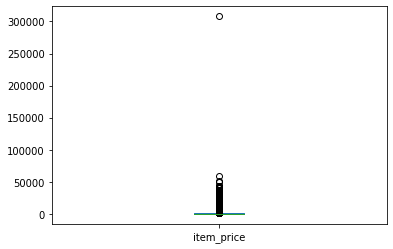

```python
final_train['item_price'].plot(kind='box')
```

```python
final_train.loc[final_train['item_price'] > 250000]
```

|  | date | date_block_num | shop_id | item_id | item_price | item_cnt_day | shop_name | item_name | item_category_id | item_category_name |
| --- | --- | --- | --- | --- | --- | --- | --- | --- | --- | --- |
| 2897558 | 13.12.2013 | 11 | 12 | 6066 | 307980.0 | 1.0 | Интернет-магазин ЧС | Radmin 3 - 522 лиц. | 75 | Программы - Для дома и офиса |

```python
test.loc[test['item_id'] == 6066] # It is not present in the test dataset
```

|  | ID | shop_id | item_id |
| --- | --- | --- | --- |

### Outliers in item_cnt_day

```python
final_train.sort_values(by=['item_cnt_day'])
```

|  | date | date_block_num | shop_id | item_id | item_price | item_cnt_day | shop_name | item_name | item_category_id | item_category_name |
| --- | --- | --- | --- | --- | --- | --- | --- | --- | --- | --- |
| 2591237 | 02.11.2013 | 10 | 12 | 8023 | 15.000000 | -22.0 | Интернет-магазин ЧС | ZL004 Лазерные наклейки Смайлики маленькие | 66 | Подарки - Открытки, наклейки |
| 921700 | 10.07.2014 | 18 | 14 | 20949 | 5.000000 | -16.0 | Казань ТЦ "ПаркХаус" II | Фирменный пакет майка 1С Интерес белый (34*42)... | 71 | Подарки - Сумки, Альбомы, Коврики д/мыши |
| 2004925 | 10.10.2014 | 21 | 12 | 9242 | 1433.333333 | -9.0 | Интернет-магазин ЧС | Билет "ИгроМир 2014" (на один день (отдельно -... | 8 | Билеты (Цифра) |
| 1349520 | 19.10.2013 | 9 | 42 | 3732 | 2599.000000 | -6.0 | СПб ТК "Невский Центр" | Grand Theft Auto V [PS3, русские субтитры] | 19 | Игры - PS3 |
| 2895348 | 18.01.2013 | 0 | 12 | 1590 | 2599.000000 | -6.0 | Интернет-магазин ЧС | Assassin’s Creed 3. Freedom Edition [PC, русск... | 29 | Игры PC - Коллекционные издания |
| ... | ... | ... | ... | ... | ... | ... | ... | ... | ... | ... |
| 2374613 | 14.04.2015 | 27 | 12 | 3731 | 1904.548077 | 624.0 | Интернет-магазин ЧС | Grand Theft Auto V [PC, русские субтитры] | 30 | Игры PC - Стандартные издания |
| 2933817 | 30.09.2015 | 32 | 55 | 9249 | 1702.825746 | 637.0 | Цифровой склад 1С-Онлайн | Билет "ИгроМир 2015" - 3 октября 2015 (сайт) У... | 8 | Билеты (Цифра) |
| 2898413 | 30.09.2015 | 32 | 12 | 9248 | 1692.526158 | 669.0 | Интернет-магазин ЧС | Билет "ИгроМир 2015" - 3 октября 2015 (сайт) [... | 80 | Служебные - Билеты |
| 922455 | 15.01.2015 | 24 | 12 | 20949 | 4.000000 | 1000.0 | Интернет-магазин ЧС | Фирменный пакет майка 1С Интерес белый (34*42)... | 71 | Подарки - Сумки, Альбомы, Коврики д/мыши |
| 2896762 | 28.10.2015 | 33 | 12 | 11373 | 0.908714 | 2169.0 | Интернет-магазин ЧС | Доставка до пункта выдачи (Boxberry) | 9 | Доставка товара |

2935843 rows × 10 columns

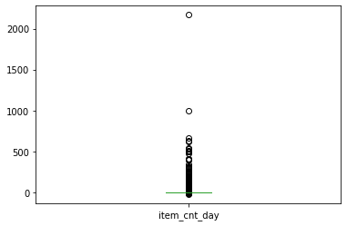

```python
final_train['item_cnt_day'].plot(kind='box')
```

## Dealing with Outliers

### item_price outliers

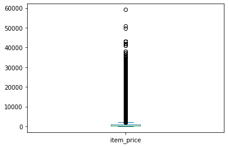

```python
clean_train = final_train.loc[final_train['item_id'] != 6066] # Removing the outlier whose price is 307980.0
clean_train = clean_train.loc[clean_train['item_price'] > 0] # Removing the outlier whose price is -1

clean_train['item_price'].plot(kind='box')
```

### item_cnt_day outliers

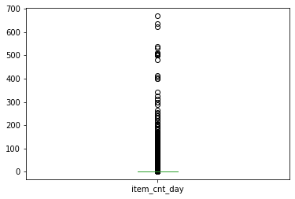

```python
clean_train['item_cnt_day'] = clean_train['item_cnt_day'].abs() # Converting the negative prices to positive values
clean_train['item_cnt_day'] = clean_train['item_cnt_day'].astype('int64') # Number of items cannot be decimal
clean_train = clean_train.loc[clean_train['item_cnt_day'] < 1000]

clean_train['item_cnt_day'].plot(kind='box')
```

## Splitting the data to target and features

```python
clean_train.corr() #Not much correlation between features
```

|  | date_block_num | shop_id | item_id | item_price | item_cnt_day | item_category_id |
| --- | --- | --- | --- | --- | --- | --- |
| date_block_num | 1.000000 | 0.019275 | 0.009355 | 0.095548 | 0.010321 | 0.029128 |
| shop_id | 0.019275 | 1.000000 | 0.029396 | -0.024086 | -0.005665 | 0.019382 |
| item_id | 0.009355 | 0.029396 | 1.000000 | -0.134790 | 0.018921 | 0.369430 |
| item_price | 0.095548 | -0.024086 | -0.134790 | 1.000000 | 0.014322 | -0.255052 |
| item_cnt_day | 0.010321 | -0.005665 | 0.018921 | 0.014322 | 1.000000 | 0.016991 |
| item_category_id | 0.029128 | 0.019382 | 0.369430 | -0.255052 | 0.016991 | 1.000000 |

We need to predict the number of items sold in November 2015 using *shop_id* and *item_id*. So we keep the *shop_id*, *item_id*, and *item_cnt_day* columns in the training set. Additionaly we also keep the *date_block_num* column as well, since we need information regarding the months since list of shops and products change every month.

```python
clean_train.sample(3)
```

|  | date | date_block_num | shop_id | item_id | item_price | item_cnt_day | shop_name | item_name | item_category_id | item_category_name |
| --- | --- | --- | --- | --- | --- | --- | --- | --- | --- | --- |
| 1686687 | 08.03.2015 | 26 | 18 | 5581 | 499.0 | 1 | Красноярск ТЦ "Июнь" | PS Vita 1000: Рукоятки Hori Grip Attachment съ... | 5 | Аксессуары - PSVita |
| 1616375 | 16.07.2014 | 18 | 27 | 6472 | 699.0 | 1 | Москва ТЦ "МЕГА Белая Дача II" | Sims 3 Вперед в будущее [PC, русская версия] | 28 | Игры PC - Дополнительные издания |
| 364540 | 13.11.2013 | 10 | 22 | 15780 | 199.0 | 1 | Москва Магазин С21 | НОГГАНО Тёплый | 55 | Музыка - CD локального производства |

```python
new1_train = clean_train.drop(columns=['date','item_price','shop_name','item_name','item_category_id','item_category_name'])
new1_train.head(3)
```

|  | date_block_num | shop_id | item_id | item_cnt_day |
| --- | --- | --- | --- | --- |
| 0 | 0 | 59 | 22154 | 1 |
| 1 | 0 | 25 | 22154 | 1 |
| 2 | 0 | 25 | 22154 | 1 |

```python
#X = new1_train.loc[:,['date_block_num','shop_id','item_id']] # Features
#y = new1_train.loc[:,'item_cnt_day'] # Targets
```

```python
#from sklearn.preprocessing import StandardScaler
from sklearn.model_selection import train_test_split
```

```python
X_train = new1_train.loc[new1_train['date_block_num']!=33]
X_test = new1_train.loc[new1_train['date_block_num']==33]
y_train = X_train.pop('item_cnt_day')
y_test = X_test.pop('item_cnt_day')
```

### ML Models

```python
scores_data = [] # Store the scores of the models
```

**Linear Regression**

```python
from sklearn.linear_model import LinearRegression
```

```python
lr = LinearRegression()
lr.fit(X_train, y_train)

scores_data.append(['Linear Regression (LR)', lr.score(X_test, y_test)])
print('Linear Regression (LR):',lr.score(X_test, y_test))
```

```
Linear Regression (LR): 0.0010571819865516918
```

**Polynomial Regression**

```python
from sklearn.preprocessing import PolynomialFeatures
```

```python
lr = LinearRegression()
for i in range(2,4):
    polyr = PolynomialFeatures(degree=i)
    X_poly = polyr.fit_transform(X_train)
    X_polyt = polyr.transform(X_test)

    name = "Polynomial Regression (n=" + str(i) + ")"

    lr.fit(X_poly, y_train)
    scores_data.append([name, lr.score(X_polyt, y_test)])

    print('Degree',i,':',lr.score(X_polyt, y_test))
```

```
Degree 2 : 0.0015835982145848693
Degree 3 : 0.0021203330906579554
```

### Improvement I

Considering only the same months as the target month.

```python
X_train = new1_train.loc[(new1_train.date_block_num==21) | (new1_train.date_block_num==9)]
#X_test is the same
y_train = X_train.pop('item_cnt_day')
#y_test is the same
```

```python
lr = LinearRegression()
lr.fit(X_train, y_train)

scores_data.append(['LR (October)', lr.score(X_test, y_test)])
print('LR (October):',lr.score(X_test, y_test))
```

```
LR (October): 0.0013438472827603798
```

### Improvement II - Reshaping the Data

Pivoting the table

```python
new2_train = new1_train.groupby(['date_block_num','shop_id','item_id']).sum()
```

```python
new2_train
```

| date_block_num | shop_id | item_id | item_cnt_day |
| --- | --- | --- | --- |
| 0 | 0 | 32 | 6 |
|  |  | 33 | 3 |
|  |  | 35 | 1 |
|  |  | 43 | 1 |
|  |  | 51 | 2 |
| ... | ... | ... | ... |
| 33 | 59 | 22087 | 6 |
|  |  | 22088 | 2 |
|  |  | 22091 | 1 |
|  |  | 22100 | 1 |
|  |  | 22102 | 1 |

1609122 rows × 1 columns

```python
new3_train = new2_train.pivot_table(index=['shop_id','item_id'], columns='date_block_num', values='item_cnt_day', fill_value=0)
new3_train.head(5)
```

| shop_id | date_block_num item_id | 0 | 1 | 2 | 3 | 4 | 5 | 6 | 7 | 8 | 9 | ... | 24 | 25 | 26 | 27 | 28 | 29 | 30 | 31 | 32 | 33 |
| --- | --- | --- | --- | --- | --- | --- | --- | --- | --- | --- | --- | --- | --- | --- | --- | --- | --- | --- | --- | --- | --- | --- |
| 0 | 30 | 0 | 31 | 0 | 0 | 0 | 0 | 0 | 0 | 0 | 0 | ... | 0 | 0 | 0 | 0 | 0 | 0 | 0 | 0 | 0 | 0 |
|  | 31 | 0 | 11 | 0 | 0 | 0 | 0 | 0 | 0 | 0 | 0 | ... | 0 | 0 | 0 | 0 | 0 | 0 | 0 | 0 | 0 | 0 |
|  | 32 | 6 | 10 | 0 | 0 | 0 | 0 | 0 | 0 | 0 | 0 | ... | 0 | 0 | 0 | 0 | 0 | 0 | 0 | 0 | 0 | 0 |
|  | 33 | 3 | 3 | 0 | 0 | 0 | 0 | 0 | 0 | 0 | 0 | ... | 0 | 0 | 0 | 0 | 0 | 0 | 0 | 0 | 0 | 0 |
|  | 35 | 1 | 14 | 0 | 0 | 0 | 0 | 0 | 0 | 0 | 0 | ... | 0 | 0 | 0 | 0 | 0 | 0 | 0 | 0 | 0 | 0 |

5 rows × 34 columns

```python
# Train test split

X = new3_train.drop(columns=33)
y = new3_train[33].values

X_train, X_test, y_train, y_test = train_test_split(X, y, test_size=0.3, random_state=0)
```

**Linear Regression**

```python
lr = LinearRegression()
lr.fit(X_train,y_train)

scores_data.append(['LR (Reshaping)', lr.score(X_test, y_test)])
print('LR (Reshaping):',lr.score(X_test, y_test))
```

```
LR (Reshaping): 0.7083529650637003
```

**Polynomial Regression**

Poly regression takes up too much space due to the large number of features.

### Score Improvement

```python
pd.DataFrame(scores_data, columns=['Model', 'Score'])
```

|  | Model | Score |
| --- | --- | --- |
| 0 | Linear Regression (LR) | 0.001057 |
| 1 | Polynomial Regression (n=2) | 0.001584 |
| 2 | Polynomial Regression (n=3) | 0.002120 |
| 3 | LR (October) | 0.001344 |
| 4 | LR (Reshaping) | 0.708353 |